# 10_mult_mats_dgrm_B

## 10_mult_mats_dgrm_B

#### Question

1. Let matrices $A$ and $B$ be defined below.

   $$A = \begin{bmatrix}
   2 & 5 & 3\\
   4 & 9 & 1\\
   6 & 8 & 7
   \end{bmatrix}$$
   $$B = \begin{bmatrix}
   4 & 3 & 9\\
   1 & 6 & 2\\
   7 & 8 & 5
   \end{bmatrix}$$

   A third matrix, $C$, is equal to the [product](https://en.wikipedia.org/wiki/Matrix_multiplication) $AB$. A student set up a diagram to help find the product:

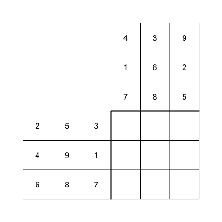

   What is $c_{1,3}$?

#### Question

2. Let matrices $A$ and $B$ be defined below.

   $$A = \begin{bmatrix}
   6 & 4 & 1\\
   7 & 3 & 8\\
   9 & 5 & 2
   \end{bmatrix}$$
   $$B = \begin{bmatrix}
   4 & 3 & 1\\
   7 & 8 & 6\\
   5 & 9 & 2
   \end{bmatrix}$$

   A third matrix, $C$, is equal to the [product](https://en.wikipedia.org/wiki/Matrix_multiplication) $AB$. A student set up a diagram to help find the product:

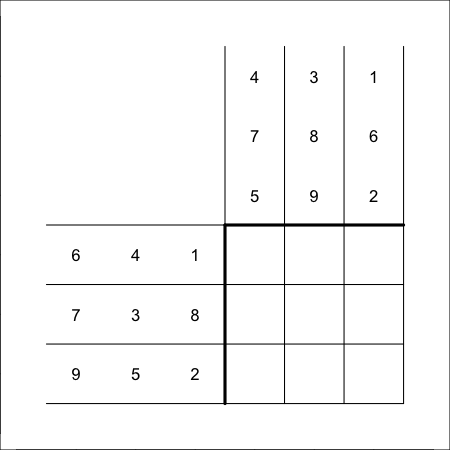

   What is $c_{3,1}$?

#### Question

3. Let matrices $A$ and $B$ be defined below.

   $$A = \begin{bmatrix}
   9 & 1 & 6\\
   3 & 8 & 7\\
   5 & 2 & 4
   \end{bmatrix}$$
   $$B = \begin{bmatrix}
   4 & 2 & 9\\
   5 & 7 & 1\\
   6 & 3 & 8
   \end{bmatrix}$$

   A third matrix, $C$, is equal to the [product](https://en.wikipedia.org/wiki/Matrix_multiplication) $AB$. A student set up a diagram to help find the product:

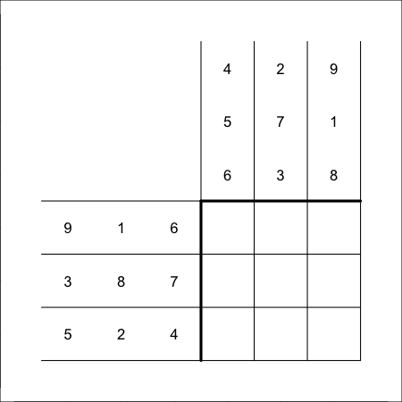

   What is $c_{2,1}$?

#### Question

4. Let matrices $A$ and $B$ be defined below.

   $$A = \begin{bmatrix}
   7 & 4 & 8\\
   6 & 2 & 5\\
   9 & 1 & 3
   \end{bmatrix}$$
   $$B = \begin{bmatrix}
   4 & 2 & 5\\
   8 & 7 & 9\\
   1 & 3 & 6
   \end{bmatrix}$$

   A third matrix, $C$, is equal to the [product](https://en.wikipedia.org/wiki/Matrix_multiplication) $AB$. A student set up a diagram to help find the product:

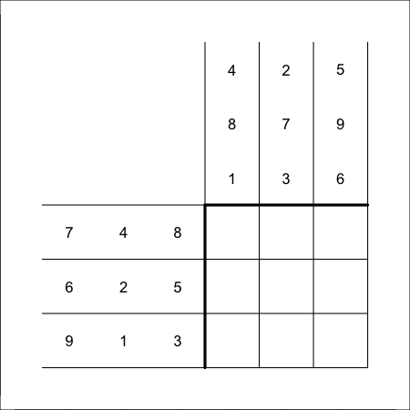

   What is $c_{1,3}$?

#### Question

5. Let matrices $A$ and $B$ be defined below.

   $$A = \begin{bmatrix}
   1 & 8 & 3\\
   4 & 5 & 7\\
   2 & 6 & 9
   \end{bmatrix}$$
   $$B = \begin{bmatrix}
   6 & 4 & 7\\
   5 & 1 & 9\\
   2 & 8 & 3
   \end{bmatrix}$$

   A third matrix, $C$, is equal to the [product](https://en.wikipedia.org/wiki/Matrix_multiplication) $AB$. A student set up a diagram to help find the product:

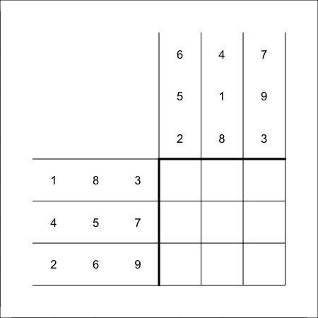

   What is $c_{3,1}$?

#### Question

6. Let matrices $A$ and $B$ be defined below.

   $$A = \begin{bmatrix}
   2 & 8 & 9\\
   6 & 4 & 3\\
   7 & 1 & 5
   \end{bmatrix}$$
   $$B = \begin{bmatrix}
   2 & 4 & 1\\
   7 & 5 & 6\\
   3 & 8 & 9
   \end{bmatrix}$$

   A third matrix, $C$, is equal to the [product](https://en.wikipedia.org/wiki/Matrix_multiplication) $AB$. A student set up a diagram to help find the product:

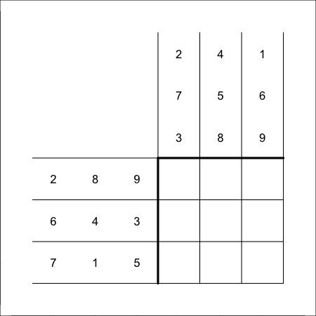

   What is $c_{2,3}$?

#### Question

7. Let matrices $A$ and $B$ be defined below.

   $$A = \begin{bmatrix}
   4 & 3 & 2\\
   5 & 7 & 8\\
   1 & 9 & 6
   \end{bmatrix}$$
   $$B = \begin{bmatrix}
   1 & 8 & 2\\
   5 & 6 & 3\\
   4 & 7 & 9
   \end{bmatrix}$$

   A third matrix, $C$, is equal to the [product](https://en.wikipedia.org/wiki/Matrix_multiplication) $AB$. A student set up a diagram to help find the product:

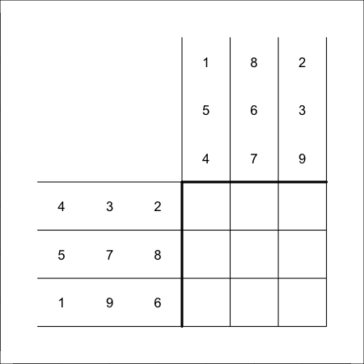

   What is $c_{1,3}$?

#### Question

8. Let matrices $A$ and $B$ be defined below.

   $$A = \begin{bmatrix}
   8 & 9 & 6\\
   5 & 3 & 2\\
   1 & 4 & 7
   \end{bmatrix}$$
   $$B = \begin{bmatrix}
   5 & 8 & 4\\
   9 & 3 & 7\\
   6 & 2 & 1
   \end{bmatrix}$$

   A third matrix, $C$, is equal to the [product](https://en.wikipedia.org/wiki/Matrix_multiplication) $AB$. A student set up a diagram to help find the product:

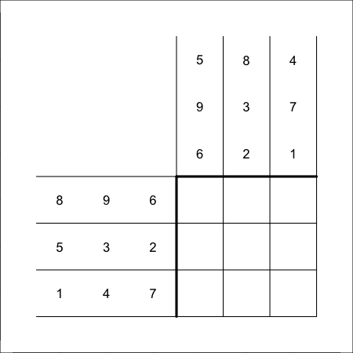

   What is $c_{3,2}$?